# Lecture 6 - An introduction to social neuroscience

# An introduction to social neuroscience

## Overview

- Aims, context and brief history
- Neuroscience methods
- The “Social Brain”

## Social cognition

What is social cognition?

- Cognition – a group of mental processes
- Social – pertains to interacting with others
- Social cognition – mental processes involved during interactions with others

## Social neuroscience

Social cognition and social neuroscience are two related fields of research

They concern different levels of description Morton (2004):

- cognitive
- neural

This reflects the fact that mental processes, including social ones, have a biological basis in the brain

## History

The emergence of social neuroscience Cacioppo & Berntson (1992).

John Cacioppo

See video - http://vimeo.com/7939053

From 25s to 1 min 25s

## History

[video not shown]

## Key points

> Humans create emergent organizations beyond the individual - structures that range from dyads, families, and groups to cities, civilizations, and international alliances.

## Key points

> These emergent structures evolved hand in hand with neural, hormonal, cellular, and genetic mechanisms to support them because the consequent social behaviors helped humans survive, reproduce, and care for offspring sufficiently long that they too survived to reproduce.

## Key points

- Previously, cognition comprised a “mental mansion” and the “social” aspect was irrelevant.
- Things are changing…

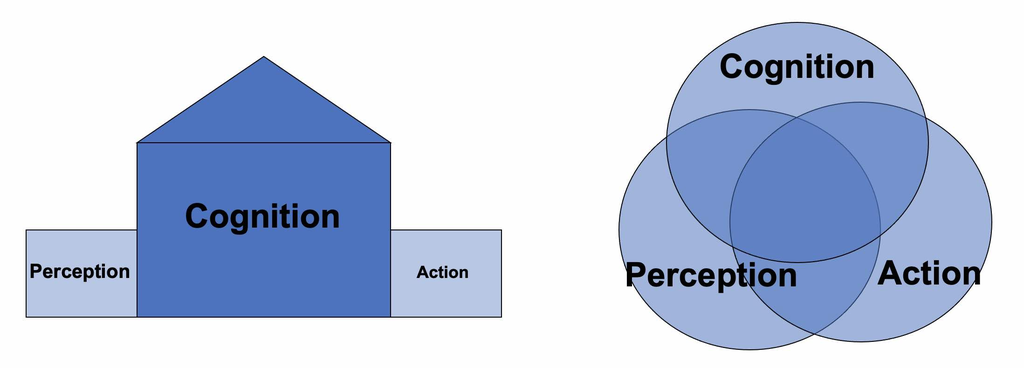

## Key points

- There are many ways to study social neuroscience (hormonal, genetic, cellular, neural)
- In this course we focus on the neural level

[figure not shown]

[figure not shown]

# Neuroscience methods

## Neuroscience methods overview

1. Direct neuronal recordings
2. ERPs - event related potentials
3. fMRI – functional magnetic resonance imaging
4. TMS – Transcranial magnetic stimulation

We will touch on these other techniques later:

- Measuring behaviour – reaction times, error rates, movement patterns etc.
- Variation across individuals and neuropsychology

## Direct neuronal recordings

- Rare in humans, except during brain surgery
- More common in non-human animals

[figure not shown]

**Advantages:** precise temporal and spatial resolution

**Disadvantages:** rarely performed in humans and very invasive!!

## ERPs

- Indirect measure of electrical activity from the scalp

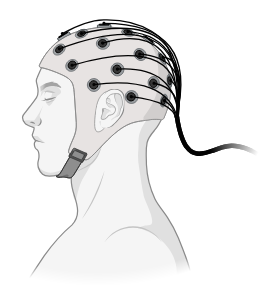

**Advantages:** precise temporal resolution, non-invasive

**Disadvantages:** indirect, poor spatial resolution

## MRI and fMRI

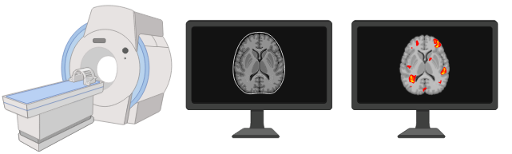

**Advantages:** good spatial resolution (*where* in the brain)

**Disadvantages:** poor temporal resolution (*when* in the brain), expensive, noisy

## TMS

- A magnetic field pulse induces electric currents in the body/brain
- If positioned on the head this current can excite the brain and create temporary disorder

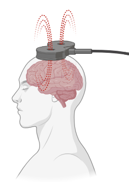

## TMS

**Advantages:** induces temporary “lesions” without permanent changes, good spatial and temporal resolution. Some researchers argue it can be used to establish causality

**Disadvantages:** only regions on the cortical surface can be stimulated, strict ethics, can be unpleasant for subjects, localisation uncertainty (i.e., spread of stimulation to many sites)

## Neuroscience methods summary

- Direct recordings - rare in humans (obviously)
- ERPs - temporal (*when* in the brain)
- fMRI - spatial (*where* in the brain)
- TMS - causal* (*according to some people)

# The “Social Brain”

## The social brain

[figure not shown]

## Background

- Brothers (1990) coined the phrase ‘social brain’
- How does the brain process social information?
- How does the brain encode, retrieve and process social information in order to produce adaptive behaviour?
- Key proponents: Chris and Uta Frith, Raplh Adolphs, Matthew Lieberman and many others

## The social brain in action

- Face recognition
- Gaze
- Emotion
- Mental states
- Trait inference
- Imitation

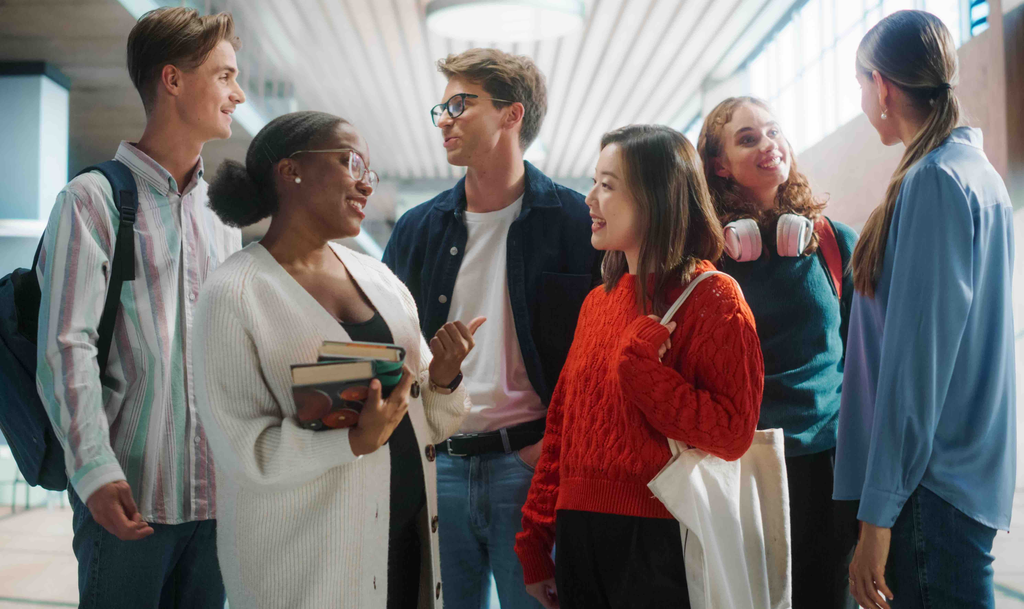

## Stranded on an alien planet…

- Are there living beings?
- Are they friendly or hostile?
- Are they like you?
- If you need help, will they cooperate and will you help them?
- Your social brain can guide you …

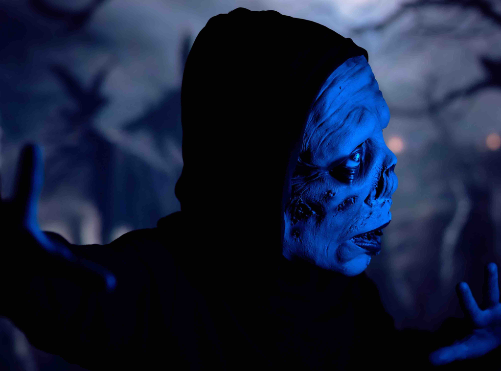

(Frith & Frith, 2010)

## Social brain circuits

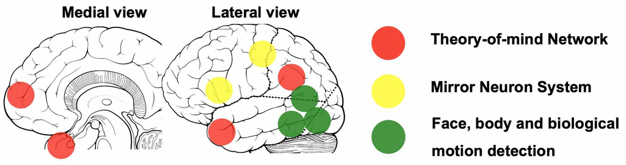

(Adolphs, 2009; Stanley & Adolphs, 2013)